# Part I - Prosper Loan Data

## Introduction

> The data consists of information about 113,937 loans granted by Prosper. This includes the Prosper score, listing category (loan type), employment status, number of current credit lines, number of open revolving accounts, debt to income ratio, and original loan amount. The list is extensive.

> The following varaibles are included in the dataset:
> - ListingKey: Unique key for each listing, same value as the 'key' used in the listing object in the API.
> - ListingNumber: The number that uniquely identifies the listing to the public as displayed on the website.
> - ListingCreationDate: The date the listing was created.
> - CreditGrade: The Credit rating that was assigned at the time the listing went live. Applicable for listings pre-2009 period and will only be populated for those listings.
> - Term: The length of the loan expressed in months.
> - LoanStatus: The current status of the loan: Cancelled, Chargedoff, Completed, Current, Defaulted, FinalPaymentInProgress, PastDue. The PastDue status will be accompanied by a delinquency bucket.
> - ClosedDate: Closed date is applicable for Cancelled, Completed, Chargedoff and Defaulted loan statuses.
> - BorrowerAPR: The Borrower's Annual Percentage Rate (APR) for the loan.
> - BorrowerRate: The Borrower's interest rate for this loan.
> - LenderYield: The Lender yield on the loan. Lender yield is equal to the interest rate on the loan less the servicing fee.
> - EstimatedEffectiveYield: Effective yield is equal to the borrower interest rate (i) minus the servicing fee rate, (ii) minus estimated uncollected interest on charge-offs, (iii) plus estimated collected late fees. Applicable for loans originated after July 2009.
> - EstimatedLoss: Estimated loss is the estimated principal loss on charge-offs. Applicable for loans originated after July 2009.
> - EstimatedReturn: The estimated return assigned to the listing at the time it was created. Estimated return is the difference between the Estimated Effective Yield and the Estimated Loss Rate. Applicable for loans originated after July 2009.
> - ProsperRating (numeric) The Prosper Rating assigned at the time the listing was created: 0 - N/A, 1 - HR, 2 - E, 3 - D, C, 5 - B, 6 - A, 7 - AA. Applicable for loans originated after July 2009.
> - ProsperRating (Alpha) The Prosper Rating assigned at the time the listing was created between AA - HR. Applicable for loans originated after July 2009.
> - ProsperScore: A custom risk score built using historical Prosper data. The score ranges from 1-10, with 10 being the best, or lowest risk score. Applicable for loans originated after July 2009.
> - ListingCategory: The category of the listing that the borrower selected when posting their listing: 0 - Not Available, 1 - Debt Consolidation, 2 - Home Improvement, 3 - Business, 4 - Personal Loan, 5 - Student Use, 6 - Auto, 7- Other, 8 - Baby&Adoption, 9 - Boat, 10 - Cosmetic Procedure, 11 - Engagement Ring, 12 - Green Loans, 13 - Household Expenses, 14 - Large Purchases, 15 - Medical/Dental, 16 - Motorcycle, 17 - RV, 18 - Taxes, 19 - Vacation, 20 - Wedding Loans
> - BorrowerState: The two letter abbreviation of the state of the address of the borrower at the time the Listing was created.
> - Occupation: The Occupation selected by the Borrower at the time they created the listing.
> - EmploymentStatus: The employment status of the borrower at the time they posted the listing.
> - EmploymentStatusDuration: The length in months of the employment status at the time the listing was created.
> - IsBorrowerHomeowner: A Borrower will be classified as a homowner if they have a mortgage on their credit profile or provide documentation confirming they are a homeowner.
> - CurrentlyInGroup: Specifies whether or not the Borrower was in a group at the time the listing was created.
> - GroupKey: The Key of the group in which the Borrower is a member of. Value will be null if the borrower does not have a group affiliation.
> - DateCreditPulled: The date the credit profile was pulled.
> - CreditScoreRangeLower: The lower value representing the range of the borrower's credit score as provided by a consumer credit rating agency.
> - CreditScoreRangeUpper: The upper value representing the range of the borrower's credit score as provided by a consumer credit rating agency.
> - FirstRecordedCreditLine: The date the first credit line was opened.
> - CurrentCreditLines: Number of current credit lines at the time the credit profile was pulled.
> - OpenCreditLines: Number of open credit lines at the time the credit profile was pulled.
> - TotalCreditLinespast7years: Number of credit lines in the past seven years at the time the credit profile was pulled.
> - OpenRevolvingAccounts: Number of open revolving accounts at the time the credit profile was pulled.
> - OpenRevolvingMonthlyPayment: Monthly payment on revolving accounts at the time the credit profile was pulled.
> - InquiriesLast6Months: Number of inquiries in the past six months at the time the credit profile was pulled.
> - TotalInquiries: Total number of inquiries at the time the credit profile was pulled.
> - CurrentDelinquencies: Number of accounts delinquent at the time the credit profile was pulled.
> - AmountDelinquent: Dollars delinquent at the time the credit profile was pulled.
> - DelinquenciesLast7Years: Number of delinquencies in the past 7 years at the time the credit profile was pulled.
> - PublicRecordsLast10Years: Number of public records in the past 10 years at the time the credit profile was pulled.
> - PublicRecordsLast12Months: Number of public records in the past 12 months at the time the credit profile was pulled.
> - RevolvingCreditBalance: Dollars of revolving credit at the time the credit profile was pulled.
> - BankcardUtilization: The percentage of available revolving credit that is utilized at the time the credit profile was pulled.
> - AvailableBankcardCredit: The total available credit via bank card at the time the credit profile was pulled.
> - TotalTrades: Number of trade lines ever opened at the time the credit profile was pulled.
> - TradesNeverDelinquent: Number of trades that have never been delinquent at the time the credit profile was pulled.
> - TradesOpenedLast6Months: Number of trades opened in the last 6 months at the time the credit profile was pulled.
> - DebtToIncomeRatio: The debt to income ratio of the borrower at the time the credit profile was pulled. This value is Null if the debt to income ratio is not available. This value is capped at 10.01 (any debt to income ratio larger than 1000% will be returned as 1001%).
> - IncomeRange: The income range of the borrower at the time the listing was created.
> - IncomeVerifiable: The borrower indicated they have the required documentation to support their income.
> - StatedMonthlyIncome: The monthly income the borrower stated at the time the listing was created.
> - LoanKey: Unique key for each loan. This is the same key that is used in the API.
> - TotalProsperLoans: Number of Prosper loans the borrower at the time they created this listing. This value will be null if the borrower had no prior loans.
> - TotalProsperPaymentsBilled: Number of on time payments the borrower made on Prosper loans at the time they created this listing. This value will be null if the borrower had no prior loans.
> - OnTimeProsperPayments: Number of on time payments the borrower had made on Prosper loans at the time they created this listing. This value will be null if the borrower has no prior loans.
> - ProsperPaymentsLessThanOneMonthLate: Number of payments the borrower made on Prosper loans that were less than one month late at the time they created this listing. This value will be null if the borrower had no prior loans.
> - ProsperPaymentsOneMonthPlusLate: Number of payments the borrower made on Prosper loans that were greater than one month late at the time they created this listing. This value will be null if the borrower had no prior loans.
> - ProsperPrincipalBorrowed: Total principal borrowed on Prosper loans at the time the listing was created. This value will be null if the borrower had no prior loans.
> - ProsperPrincipalOutstanding: Principal outstanding on Prosper loans at the time the listing was created. This value will be null if the borrower had no prior loans.
> - ScorexChangeAtTimeOfListing: Borrower's credit score change at the time the credit profile was pulled. This will be the change relative to the borrower's last Prosper loan. This value will be null if the borrower had no prior loans.
> - LoanCurrentDaysDelinquent: The number of days delinquent.
> - LoanFirstDefaultedCycleNumber: The cycle the loan was charged off. If the loan has not charged off the value will be null.
> - LoanMonthsSinceOrigination: Number of months since the loan originated.
> - LoanNumber: Unique numeric value associated with the loan.
> - LoanOriginalAmount: The origination amount of the loan.
> - LoanOriginationDate: The date the loan was originated.
> - LoanOriginationQuarter: The quarter in which the loan was originated.
> - MemberKey: The unique key that is associated with the borrower. This is the same identifier that is used in the API member object.
> - MonthlyLoanPayment: The scheduled monthly loan payment.
> - LP_CustomerPayments: Pre charge-off cumulative gross payments made by the borrower on the loan. If the loan has charged off, this value will exclude any recoveries.
> - LP_CustomerPrincipalPayments: Pre charge-off cumulative principal payments made by the borrower on the loan. If the loan has charged off, this value will exclude any recoveries.
> - LP_InterestandFees; Pre charge-off cumulative interest and fees paid by the borrower. If the loan has charged off, this value will exclude any recoveries.
> - LP_ServiceFees: Cumulative service fees paid by the investors who have invested in the loan.
> - LP_CollectionFees: Cumulative collection fees paid by the investors who have invested in the loan.
> - LP_GrossPrincipalLoss: The gross charged off amount of the loan.
> - LP_NetPrincipalLoss: The principal that remains uncollected after any recoveries.
> - LP_NonPrincipalRecoverypayments: The interest and fee component of any recovery payments. The current payment policy applies payments in the following order: Fees, interest, principal.
> - PercentFunded: Percent the listing was funded.
> - Recommendations: Number of recommendations the borrower had at the time the listing was created.
> - InvestmentFromFriendsCount: Number of friends that made an investment in the loan.
> - InvestmentFromFriendsAmount: Dollar amount of investments that were made by friends.
> - Investors: The number of investors that funded the loan.

## Preliminary Wrangling

```python
# import all packages and set plots to be embedded inline
import numpy as np
import pandas as pd
import matplotlib.pyplot as plt
import seaborn as sb

%matplotlib inline
```

> Load dataset and investigate the properties and structure of the dataset

```python
# load in the dataset into a pandas dataframe, print statistics
data = pd.read_csv('prosperLoanData.csv')
```

```python
# high-level overview of data shape and composition
print(data.shape)
print(data.dtypes)
print(data.head(10))
```

```
(113937, 81)
ListingKey                              object
ListingNumber                            int64
ListingCreationDate                     object
CreditGrade                             object
Term                                     int64
LoanStatus                              object
ClosedDate                              object
BorrowerAPR                            float64
BorrowerRate                           float64
LenderYield                            float64
EstimatedEffectiveYield                float64
EstimatedLoss                          float64
EstimatedReturn                        float64
ProsperRating (numeric)                float64
ProsperRating (Alpha)                   object
ProsperScore                           float64
ListingCategory (numeric)                int64
BorrowerState                           object
Occupation                              object
EmploymentStatus                        object
EmploymentStatusDuration               float64
IsBorrowerHomeowner                       bool
CurrentlyInGroup                          bool
GroupKey                                object
DateCreditPulled                        object
CreditScoreRangeLower                  float64
CreditScoreRangeUpper                  float64
FirstRecordedCreditLine                 object
CurrentCreditLines                     float64
OpenCreditLines                        float64
                                        ...
TotalProsperLoans                      float64
TotalProsperPaymentsBilled             float64
OnTimeProsperPayments                  float64
ProsperPaymentsLessThanOneMonthLate    float64
ProsperPaymentsOneMonthPlusLate        float64
ProsperPrincipalBorrowed               float64
ProsperPrincipalOutstanding            float64
ScorexChangeAtTimeOfListing            float64
```

[output cut: 81 more lines]

```
9            1.0                0                          0

  InvestmentFromFriendsAmount Investors
0                         0.0       258
1                         0.0         1
2                         0.0        41
3                         0.0       158
4                         0.0        20
5                         0.0         1
6                         0.0         1
7                         0.0         1
8                         0.0         1
9                         0.0         1

[10 rows x 81 columns]
```

There are 113937 rows and 81 fields in the dataset. Majority of the dataset is made up of floats and object data types. There are multiple fields that one can use in this investigation, however I am going to narrow it down t focus in a few key fields.

```python
data["IncomeRange"].value_counts()
```

```
$25,000-49,999    32192
$50,000-74,999    31050
$100,000+         17337
$75,000-99,999    16916
Not displayed      7741
$1-24,999          7274
Not employed        806
$0                  621
Name: IncomeRange, dtype: int64
```

Currently the IncomeRange field is categorical, but not ordinal, which is important for when plotting plotting and investigating the dataset later.

```python
data["ProsperRating (Alpha)"].value_counts()
```

```
C     18345
B     15581
A     14551
D     14274
E      9795
HR     6935
AA     5372
Name: ProsperRating (Alpha), dtype: int64
```

Likewise for the ProsperRating (Alpha) field. The order is important as it indicates low and high risk.

It is important that these two above mentioned variables need to be ordered for the analysis.

```python
# convert ProsperRating (Alpha) and IncomeRange into ordered categorical types

ordinal_var_dict = {'ProsperRating (Alpha)': ['N/A','HR','E','D','C', 'B','A','AA'],
                    'IncomeRange': ['Not displayed', 'Not employed', '$0', '$1-24,999', '$25,000-49,999', '$50,000-74,999', '$75,000-99,999','$100,000+']}

for var in ordinal_var_dict:
    ordered_var = pd.api.types.CategoricalDtype(ordered = True,
                                                categories = ordinal_var_dict[var])
    data[var] = data[var].astype(ordered_var)
```

```python
print(data.describe())
```

```
       ListingNumber           Term    BorrowerAPR   BorrowerRate  \
count   1.139370e+05  113937.000000  113912.000000  113937.000000
mean    6.278857e+05      40.830248       0.218828       0.192764
std     3.280762e+05      10.436212       0.080364       0.074818
min     4.000000e+00      12.000000       0.006530       0.000000
25%     4.009190e+05      36.000000       0.156290       0.134000
50%     6.005540e+05      36.000000       0.209760       0.184000
75%     8.926340e+05      36.000000       0.283810       0.250000
max     1.255725e+06      60.000000       0.512290       0.497500

         LenderYield  EstimatedEffectiveYield  EstimatedLoss  EstimatedReturn  \
count  113937.000000             84853.000000   84853.000000     84853.000000
mean        0.182701                 0.168661       0.080306         0.096068
std         0.074516                 0.068467       0.046764         0.030403
min        -0.010000                -0.182700       0.004900        -0.182700
25%         0.124200                 0.115670       0.042400         0.074080
50%         0.173000                 0.161500       0.072400         0.091700
75%         0.240000                 0.224300       0.112000         0.116600
max         0.492500                 0.319900       0.366000         0.283700

       ProsperRating (numeric)  ProsperScore      ...        LP_ServiceFees  \
count             84853.000000  84853.000000      ...         113937.000000
mean                  4.072243      5.950067      ...            -54.725641
std                   1.673227      2.376501      ...             60.675425
min                   1.000000      1.000000      ...           -664.870000
25%                   3.000000      4.000000      ...            -73.180000
50%                   4.000000      6.000000      ...            -34.440000
75%                   5.000000      8.000000      ...            -13.920000
max                   7.000000     11.000000      ...             32.060000

       LP_CollectionFees  LP_GrossPrincipalLoss  LP_NetPrincipalLoss  \
count      113937.000000          113937.000000        113937.000000
mean          -14.242698             700.446342           681.420499
std           109.232758            2388.513831          2357.167068
min         -9274.750000             -94.200000          -954.550000
25%             0.000000               0.000000             0.000000
50%             0.000000               0.000000             0.000000
75%             0.000000               0.000000             0.000000
max             0.000000           25000.000000         25000.000000

       LP_NonPrincipalRecoverypayments  PercentFunded  Recommendations  \
count                    113937.000000  113937.000000    113937.000000
mean                         25.142686       0.998584         0.048027
std                         275.657937       0.017919         0.332353
min                           0.000000       0.700000         0.000000
25%                           0.000000       1.000000         0.000000
50%                           0.000000       1.000000         0.000000
75%                           0.000000       1.000000         0.000000
max                       21117.900000       1.012500        39.000000

       InvestmentFromFriendsCount  InvestmentFromFriendsAmount      Investors
count               113937.000000                113937.000000  113937.000000
mean                     0.023460                    16.550751      80.475228
std                      0.232412                   294.545422     103.239020
min                      0.000000                     0.000000       1.000000
25%                      0.000000                     0.000000       2.000000
50%                      0.000000                     0.000000      44.000000
75%                      0.000000                     0.000000     115.000000
max                     33.000000                 25000.000000    1189.000000

[8 rows x 61 columns]
```

As two of the most important fields we are investigating have null values, the decision was made to drop them as it will help investigate the influence on other factors on these variables

```python
#df.dropna(inplace = True)
data = data[data['ProsperScore'].notnull()]
data = data[~data.BorrowerAPR.isna()]
```

```python
#test if the ProsoperScore has dropped the null values
data['ProsperScore'].isna().sum()
```

```
0
```

```python
data.info()
```

```
<class 'pandas.core.frame.DataFrame'>
Int64Index: 84853 entries, 1 to 113936
Data columns (total 81 columns):
ListingKey                             84853 non-null object
ListingNumber                          84853 non-null int64
ListingCreationDate                    84853 non-null object
CreditGrade                            0 non-null object
Term                                   84853 non-null int64
LoanStatus                             84853 non-null object
ClosedDate                             26005 non-null object
BorrowerAPR                            84853 non-null float64
BorrowerRate                           84853 non-null float64
LenderYield                            84853 non-null float64
EstimatedEffectiveYield                84853 non-null float64
EstimatedLoss                          84853 non-null float64
EstimatedReturn                        84853 non-null float64
ProsperRating (numeric)                84853 non-null float64
ProsperRating (Alpha)                  84853 non-null category
ProsperScore                           84853 non-null float64
ListingCategory (numeric)              84853 non-null int64
BorrowerState                          84853 non-null object
Occupation                             83520 non-null object
EmploymentStatus                       84853 non-null object
EmploymentStatusDuration               84834 non-null float64
IsBorrowerHomeowner                    84853 non-null bool
CurrentlyInGroup                       84853 non-null bool
GroupKey                               2026 non-null object
DateCreditPulled                       84853 non-null object
CreditScoreRangeLower                  84853 non-null float64
CreditScoreRangeUpper                  84853 non-null float64
FirstRecordedCreditLine                84853 non-null object
CurrentCreditLines                     84853 non-null float64
OpenCreditLines                        84853 non-null float64
TotalCreditLinespast7years             84853 non-null float64
OpenRevolvingAccounts                  84853 non-null int64
OpenRevolvingMonthlyPayment            84853 non-null float64
InquiriesLast6Months                   84853 non-null float64
TotalInquiries                         84853 non-null float64
CurrentDelinquencies                   84853 non-null float64
AmountDelinquent                       84853 non-null float64
```

[output cut: 31 more lines]

```
LP_CustomerPayments                    84853 non-null float64
LP_CustomerPrincipalPayments           84853 non-null float64
LP_InterestandFees                     84853 non-null float64
LP_ServiceFees                         84853 non-null float64
LP_CollectionFees                      84853 non-null float64
LP_GrossPrincipalLoss                  84853 non-null float64
LP_NetPrincipalLoss                    84853 non-null float64
LP_NonPrincipalRecoverypayments        84853 non-null float64
PercentFunded                          84853 non-null float64
Recommendations                        84853 non-null int64
InvestmentFromFriendsCount             84853 non-null int64
InvestmentFromFriendsAmount            84853 non-null float64
Investors                              84853 non-null int64
dtypes: bool(3), category(2), float64(50), int64(11), object(15)
memory usage: 50.3+ MB
```

```python
#visual analysis to see how the data looks for the first 5 rows
data.head()
```

|  | ListingKey | ListingNumber | ListingCreationDate | CreditGrade | Term | LoanStatus | ClosedDate | BorrowerAPR | BorrowerRate | LenderYield | ... | LP_ServiceFees | LP_CollectionFees | LP_GrossPrincipalLoss | LP_NetPrincipalLoss | LP_NonPrincipalRecoverypayments | PercentFunded | Recommendations | InvestmentFromFriendsCount | InvestmentFromFriendsAmount | Investors |
| --- | --- | --- | --- | --- | --- | --- | --- | --- | --- | --- | --- | --- | --- | --- | --- | --- | --- | --- | --- | --- | --- |
| 1 | 10273602499503308B223C1 | 1209647 | 2014-02-27 08:28:07.900000000 | NaN | 36 | Current | NaN | 0.12016 | 0.0920 | 0.0820 | ... | 0.00 | 0.0 | 0.0 | 0.0 | 0.0 | 1.0 | 0 | 0 | 0.0 | 1 |
| 3 | 0EF5356002482715299901A | 658116 | 2012-10-22 11:02:35.010000000 | NaN | 36 | Current | NaN | 0.12528 | 0.0974 | 0.0874 | ... | -108.01 | 0.0 | 0.0 | 0.0 | 0.0 | 1.0 | 0 | 0 | 0.0 | 158 |
| 4 | 0F023589499656230C5E3E2 | 909464 | 2013-09-14 18:38:39.097000000 | NaN | 36 | Current | NaN | 0.24614 | 0.2085 | 0.1985 | ... | -60.27 | 0.0 | 0.0 | 0.0 | 0.0 | 1.0 | 0 | 0 | 0.0 | 20 |
| 5 | 0F05359734824199381F61D | 1074836 | 2013-12-14 08:26:37.093000000 | NaN | 60 | Current | NaN | 0.15425 | 0.1314 | 0.1214 | ... | -25.33 | 0.0 | 0.0 | 0.0 | 0.0 | 1.0 | 0 | 0 | 0.0 | 1 |
| 6 | 0F0A3576754255009D63151 | 750899 | 2013-04-12 09:52:56.147000000 | NaN | 36 | Current | NaN | 0.31032 | 0.2712 | 0.2612 | ... | -22.95 | 0.0 | 0.0 | 0.0 | 0.0 | 1.0 | 0 | 0 | 0.0 | 1 |

5 rows × 81 columns

The listing data is keeping unnesecassry data in the ListingCreationDate. It is important to return only the date and time and not the milliseconds recorded.

```python
def truncate_extra(row):
    if len(row.ListingCreationDate)==29:
        return row.ListingCreationDate[:-10]
    else:
        return row.ListingCreationDate
```

```python
import datetime
data.ListingCreationDate = data.apply(truncate_extra,axis=1)
data.ListingCreationDate = data.ListingCreationDate.apply(lambda x: datetime.datetime.strptime(x, "%Y-%m-%d %H:%M:%S"))

#test to see if the method worked
data.head(5)
```

|  | ListingKey | ListingNumber | ListingCreationDate | CreditGrade | Term | LoanStatus | ClosedDate | BorrowerAPR | BorrowerRate | LenderYield | ... | LP_ServiceFees | LP_CollectionFees | LP_GrossPrincipalLoss | LP_NetPrincipalLoss | LP_NonPrincipalRecoverypayments | PercentFunded | Recommendations | InvestmentFromFriendsCount | InvestmentFromFriendsAmount | Investors |
| --- | --- | --- | --- | --- | --- | --- | --- | --- | --- | --- | --- | --- | --- | --- | --- | --- | --- | --- | --- | --- | --- |
| 1 | 10273602499503308B223C1 | 1209647 | 2014-02-27 08:28:07 | NaN | 36 | Current | NaN | 0.12016 | 0.0920 | 0.0820 | ... | 0.00 | 0.0 | 0.0 | 0.0 | 0.0 | 1.0 | 0 | 0 | 0.0 | 1 |
| 3 | 0EF5356002482715299901A | 658116 | 2012-10-22 11:02:35 | NaN | 36 | Current | NaN | 0.12528 | 0.0974 | 0.0874 | ... | -108.01 | 0.0 | 0.0 | 0.0 | 0.0 | 1.0 | 0 | 0 | 0.0 | 158 |
| 4 | 0F023589499656230C5E3E2 | 909464 | 2013-09-14 18:38:39 | NaN | 36 | Current | NaN | 0.24614 | 0.2085 | 0.1985 | ... | -60.27 | 0.0 | 0.0 | 0.0 | 0.0 | 1.0 | 0 | 0 | 0.0 | 20 |
| 5 | 0F05359734824199381F61D | 1074836 | 2013-12-14 08:26:37 | NaN | 60 | Current | NaN | 0.15425 | 0.1314 | 0.1214 | ... | -25.33 | 0.0 | 0.0 | 0.0 | 0.0 | 1.0 | 0 | 0 | 0.0 | 1 |
| 6 | 0F0A3576754255009D63151 | 750899 | 2013-04-12 09:52:56 | NaN | 36 | Current | NaN | 0.31032 | 0.2712 | 0.2612 | ... | -22.95 | 0.0 | 0.0 | 0.0 | 0.0 | 1.0 | 0 | 0 | 0.0 | 1 |

5 rows × 81 columns

### What is the structure of your dataset?

> There are 113937 loan records in the dataset with 80 variable that contain important information on the loans . Most variables are numeric in nature (61 out of the 80), but the variables IncomeRange and ProsperRating (Alpha) are ordered factor variables with the following levels.

> Low ------> High

> IncomeRange: Not displayed, Not employed, $0, $1-24,999, $25,000-49,999, $50,000-74,999, $75,000-99,999, $100,000+

> Worst -----> Best

> ProsperRating (Alpha): N/A, HR, E, D, C, B, A, AA

### What is/are the main feature(s) of interest in your dataset?

> I am most interested in what are the variable to influence the interest rates (APR) the most.

### What features in the dataset do you think will help support your investigation into your feature(s) of interest?

> The following will have have an affect on the interest rates & Prosper Score:

> 1) ListingCategory - I suspect home loans & student loans have lower interest rates as they are generally taken out for longer periods of time, while engagment rings, personal loans and vacations are higher.

> 2) Employment Status - I suspect that if one is employed they shall receive a lower interest rate at they have a greater chance of paying the loan back

> 3) EmploymentStatusDuration - I suspect the longer the employment duration the lower the interest rates

> 4) IsBorrowerHomeowner - I suspect if the person already has a mortage, the interest rates will be lower

> 5) DebtToIncomeRatio - The higher the amount of debt one has to the income, the worse the prosper score and interest rare

> 6) IncomeRange - The higher the income, the better the interest rate

> 10) StatedMonthlyIncome - the higher the monthly income, the better the interest rate

> 11) ListingCreationDate - to see if the interest rate has increased over time & number of loans have increased over time

> 14) LoanOriginalAmount - the higher the loan amount, the lower the interest rate

```python
# Define columns of interest for this analysis
variables = ['ProsperScore', 'ListingCategory (numeric)', 'EmploymentStatus', 'EmploymentStatusDuration',
            'IsBorrowerHomeowner', 'DebtToIncomeRatio','IncomeRange', 'LoanOriginalAmount',
            'ProsperRating (Alpha)', 'StatedMonthlyIncome', 'BorrowerAPR', 'ListingCreationDate']
```

```python
data = data[variables]
data.head(10)
```

|  | ProsperScore | ListingCategory (numeric) | EmploymentStatus | EmploymentStatusDuration | IsBorrowerHomeowner | DebtToIncomeRatio | IncomeRange | LoanOriginalAmount | ProsperRating (Alpha) | StatedMonthlyIncome | BorrowerAPR | ListingCreationDate |
| --- | --- | --- | --- | --- | --- | --- | --- | --- | --- | --- | --- | --- |
| 1 | 7.0 | 2 | Employed | 44.0 | False | 0.18 | $50,000-74,999 | 10000 | A | 6125.000000 | 0.12016 | 2014-02-27 08:28:07 |
| 3 | 9.0 | 16 | Employed | 113.0 | True | 0.15 | $25,000-49,999 | 10000 | A | 2875.000000 | 0.12528 | 2012-10-22 11:02:35 |
| 4 | 4.0 | 2 | Employed | 44.0 | True | 0.26 | $100,000+ | 15000 | D | 9583.333333 | 0.24614 | 2013-09-14 18:38:39 |
| 5 | 10.0 | 1 | Employed | 82.0 | True | 0.36 | $100,000+ | 15000 | B | 8333.333333 | 0.15425 | 2013-12-14 08:26:37 |
| 6 | 2.0 | 1 | Employed | 172.0 | False | 0.27 | $25,000-49,999 | 3000 | E | 2083.333333 | 0.31032 | 2013-04-12 09:52:56 |
| 7 | 4.0 | 2 | Employed | 103.0 | False | 0.24 | $25,000-49,999 | 10000 | C | 3355.750000 | 0.23939 | 2013-05-05 06:49:27 |
| 8 | 9.0 | 7 | Employed | 269.0 | True | 0.25 | $25,000-49,999 | 10000 | AA | 3333.333333 | 0.07620 | 2013-12-02 10:43:39 |
| 9 | 11.0 | 7 | Employed | 269.0 | True | 0.25 | $25,000-49,999 | 10000 | AA | 3333.333333 | 0.07620 | 2013-12-02 10:43:39 |
| 10 | 7.0 | 1 | Employed | 300.0 | False | 0.12 | $75,000-99,999 | 13500 | C | 7500.000000 | 0.27462 | 2012-05-10 07:04:01 |
| 12 | 4.0 | 1 | Employed | 1.0 | False | 0.18 | $25,000-49,999 | 4000 | B | 2416.666667 | 0.17969 | 2013-12-15 20:01:10 |

```python
# Decode ListingCategory (numeric) feature by creating an explanoyory column
list_dict = {0 : 'Not Available', 1 : 'Debt Consolidation', 2 : 'Home Improvement', 3: 'Business',
             4 : 'Personal Loan', 5 : 'Student Use', 6 : 'Auto', 7 : 'Other', 8 : 'Baby&Adoption',
             9 : 'Boat', 10 : 'Cosmetic Procedure', 11 : 'Engagement Ring', 12 : 'Green Loans',
             13 : 'Household Expenses', 14 : 'Large Purchases', 15 : 'Medical/Dental', 16 : 'Motorcycle',
             17 : 'RV', 18 : 'Taxes', 19 : 'Vacation', 20 : 'Wedding Loans'}

data['ListingCategory'] = data['ListingCategory (numeric)'].map(list_dict)
```

```python
#check if it worked
data.head()
```

|  | ProsperScore | ListingCategory (numeric) | EmploymentStatus | EmploymentStatusDuration | IsBorrowerHomeowner | DebtToIncomeRatio | IncomeRange | LoanOriginalAmount | ProsperRating (Alpha) | StatedMonthlyIncome | BorrowerAPR | ListingCreationDate | ListingCategory |
| --- | --- | --- | --- | --- | --- | --- | --- | --- | --- | --- | --- | --- | --- |
| 1 | 7.0 | 2 | Employed | 44.0 | False | 0.18 | $50,000-74,999 | 10000 | A | 6125.000000 | 0.12016 | 2014-02-27 08:28:07 | Home Improvement |
| 3 | 9.0 | 16 | Employed | 113.0 | True | 0.15 | $25,000-49,999 | 10000 | A | 2875.000000 | 0.12528 | 2012-10-22 11:02:35 | Motorcycle |
| 4 | 4.0 | 2 | Employed | 44.0 | True | 0.26 | $100,000+ | 15000 | D | 9583.333333 | 0.24614 | 2013-09-14 18:38:39 | Home Improvement |
| 5 | 10.0 | 1 | Employed | 82.0 | True | 0.36 | $100,000+ | 15000 | B | 8333.333333 | 0.15425 | 2013-12-14 08:26:37 | Debt Consolidation |
| 6 | 2.0 | 1 | Employed | 172.0 | False | 0.27 | $25,000-49,999 | 3000 | E | 2083.333333 | 0.31032 | 2013-04-12 09:52:56 | Debt Consolidation |

```python
#check how the data has changed and if all the columns came through
data.info()
```

```
<class 'pandas.core.frame.DataFrame'>
Int64Index: 84853 entries, 1 to 113936
Data columns (total 13 columns):
ProsperScore                 84853 non-null float64
ListingCategory (numeric)    84853 non-null int64
EmploymentStatus             84853 non-null object
EmploymentStatusDuration     84834 non-null float64
IsBorrowerHomeowner          84853 non-null bool
DebtToIncomeRatio            77557 non-null float64
IncomeRange                  84853 non-null category
LoanOriginalAmount           84853 non-null int64
ProsperRating (Alpha)        84853 non-null category
StatedMonthlyIncome          84853 non-null float64
BorrowerAPR                  84853 non-null float64
ListingCreationDate          84853 non-null datetime64[ns]
ListingCategory              84853 non-null object
dtypes: bool(1), category(2), datetime64[ns](1), float64(5), int64(2), object(2)
memory usage: 7.4+ MB
```

```python
#replace all null values in the debt to income ratio with zero
data['DebtToIncomeRatio'] = data['DebtToIncomeRatio'].fillna(0)
```

```python
data.info()
```

```
<class 'pandas.core.frame.DataFrame'>
Int64Index: 84853 entries, 1 to 113936
Data columns (total 13 columns):
ProsperScore                 84853 non-null float64
ListingCategory (numeric)    84853 non-null int64
EmploymentStatus             84853 non-null object
EmploymentStatusDuration     84834 non-null float64
IsBorrowerHomeowner          84853 non-null bool
DebtToIncomeRatio            84853 non-null float64
IncomeRange                  84853 non-null category
LoanOriginalAmount           84853 non-null int64
ProsperRating (Alpha)        84853 non-null category
StatedMonthlyIncome          84853 non-null float64
BorrowerAPR                  84853 non-null float64
ListingCreationDate          84853 non-null datetime64[ns]
ListingCategory              84853 non-null object
dtypes: bool(1), category(2), datetime64[ns](1), float64(5), int64(2), object(2)
memory usage: 7.4+ MB
```

```python
data = data.dropna()
```

```python
data.info()
```

```
<class 'pandas.core.frame.DataFrame'>
Int64Index: 84834 entries, 1 to 113936
Data columns (total 13 columns):
ProsperScore                 84834 non-null float64
ListingCategory (numeric)    84834 non-null int64
EmploymentStatus             84834 non-null object
EmploymentStatusDuration     84834 non-null float64
IsBorrowerHomeowner          84834 non-null bool
DebtToIncomeRatio            84834 non-null float64
IncomeRange                  84834 non-null category
LoanOriginalAmount           84834 non-null int64
ProsperRating (Alpha)        84834 non-null category
StatedMonthlyIncome          84834 non-null float64
BorrowerAPR                  84834 non-null float64
ListingCreationDate          84834 non-null datetime64[ns]
ListingCategory              84834 non-null object
dtypes: bool(1), category(2), datetime64[ns](1), float64(5), int64(2), object(2)
memory usage: 7.4+ MB
```

## Univariate Exploration

This section we shall explore the distribution of the data and see if there are any abnormalities in the data.

### What is the distribution of the BorrowerAPR?

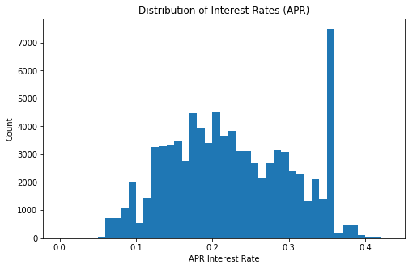

```python
# Assessing the distribution of the main variable of interest, if the
binsize = 0.01
bins = np.arange(0, data['BorrowerAPR'].max()+binsize, binsize)

plt.figure(figsize=[8, 5])
plt.hist(data = data, x = 'BorrowerAPR', bins = bins)
plt.xlabel('APR Interest Rate')
plt.ylabel('Count')
plt.title('Distribution of Interest Rates (APR)')
plt.show()
```

### Observation

The distribution looks normal except with a significant amount of interest rates of 0.36

### What is the distribution of the Loan Amounts given to applicants?

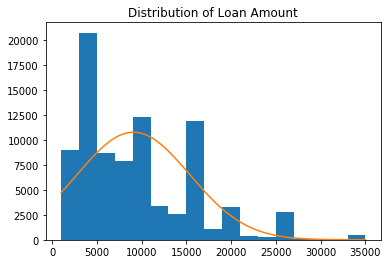

```python
# create a histogram of the data
bin_size = 2000
bin_edges = np.arange(1000, 35000 + bin_size, bin_size)
plt.hist(data = data, x = 'LoanOriginalAmount', bins = bin_edges);

# overlay a theoretical normal distribution on top
data_mean = data['LoanOriginalAmount'].mean()
data_sd = data['LoanOriginalAmount'].std()

from scipy.stats import norm
x = np.linspace(1000, 35000, 2000)
y = norm.pdf(x, data_mean, data_sd) # normal distribution heights
y *= data.shape[0] * bin_size # scale the distribution height
plt.title('Distribution of Loan Amount')

plt.plot(x, y);
```

### Observation

The loan amount is skewed to the right. With most being smaller, with a few being bigger - this makes sense as it is harder to get a bigger size loan.

### What is the main category that applicants apply for loans?

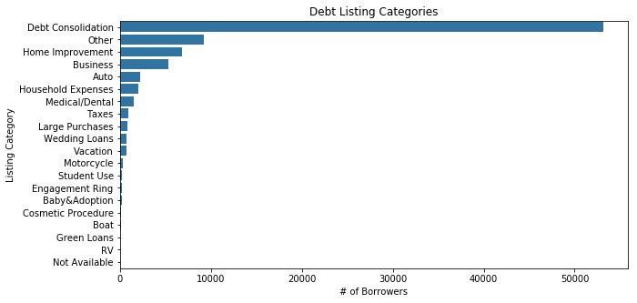

```python
# Plot for ListingCategory
plt.figure(figsize=[10, 5])
base_color = sb.color_palette()[0]
# Order the categorical variable type
cat_order = data['ListingCategory'].value_counts().index

sb.countplot(data = data, y = 'ListingCategory', color = base_color, order=cat_order)
plt.xlabel('# of Borrowers')
plt.ylabel('Listing Category')
plt.title('Debt Listing Categories');
```

### Observation

Majority of loans are actually used for debt consolidation.

### What is the distribution of the debt to income ratio?

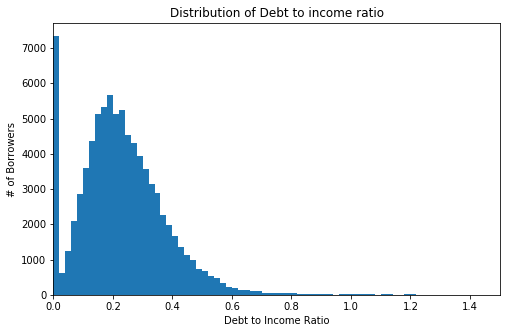

```python
# Plot a standard-scaled plot for DebtToIncomeRatio
binsize = 0.02
bins = np.arange(0, data['DebtToIncomeRatio'].max()+binsize, binsize)

plt.figure(figsize=[8, 5])
plt.hist(data = data[data['DebtToIncomeRatio'].notnull()], x = 'DebtToIncomeRatio', bins = bins)
plt.xlabel('Debt to Income Ratio')
plt.ylabel('# of Borrowers')
plt.xlim(0,1.5)
plt.title('Distribution of Debt to income ratio');
```

### Observation

```
Text(0.5,1,'Log Distribution of Debt To IncomeRatio')
```

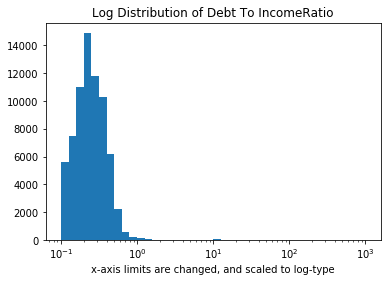

```python
#Perform log function to see if normal once converted
# Axis transformation
# Bin size
bins = 10 ** np.arange(-1, 3+0.1, 0.1)
plt.hist(data=data, x='DebtToIncomeRatio', bins=bins);

# The argument in the xscale() represents the axis scale type to apply.
# The possible values are: {"linear", "log", "symlog", "logit", ...}
plt.xscale('log')

# Apply x-axis label
# Documentatin: [matplotlib `xlabel`](https://matplotlib.org/api/_as_gen/matplotlib.pyplot.xlabel.html))
plt.xlabel('x-axis limits are changed, and scaled to log-type')
plt.title('Log Distribution of Debt To IncomeRatio')
```

### Observation

Distribution looks normal once converted to log function.

### What is the employment status of the applicants?

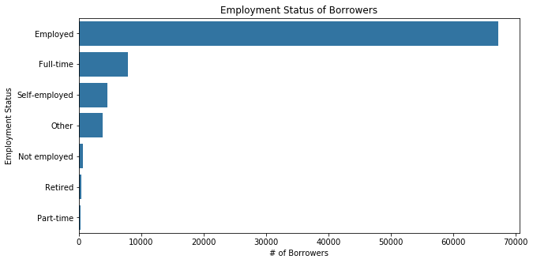

```python
# Plot for EmploymentStatus
plt.figure(figsize=[10, 5])
base_color = sb.color_palette()[0]
# Order the categorical variable type
cat_order = data['EmploymentStatus'].value_counts().index

sb.countplot(data = data, y = 'EmploymentStatus', color = base_color, order=cat_order)
plt.xlabel('# of Borrowers')
plt.ylabel('Employment Status')
plt.title('Employment Status of Borrowers');
```

### Observation

Majority of borrows are employed and receive a regular income.

### Quick Overview of the distribution of the numeric values

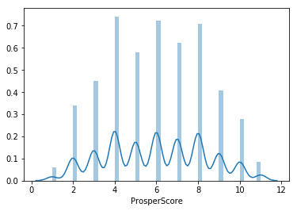

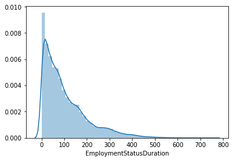

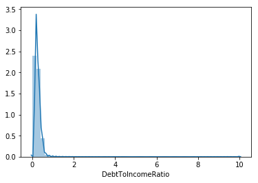

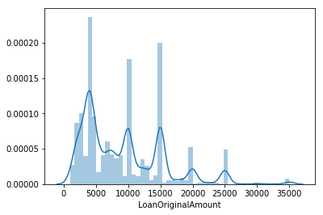

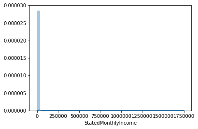

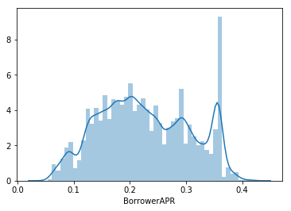

```python
#plotting all numeric variable except Debt to Income ratio as plots won't plot null values
numeric_vars = ['ProsperScore', 'EmploymentStatusDuration','DebtToIncomeRatio', 'LoanOriginalAmount', 'StatedMonthlyIncome', 'BorrowerAPR']

data_numeric = data[numeric_vars]

for i, col in enumerate(data_numeric.columns):
    plt.figure(i)
    sb.distplot(data_numeric[col])
```

### Observation

Employment duartion is skewed to the right as majority of consumers have been with the company for under 10 years.

### What is the distribution of the income ranges of the loan applicants?

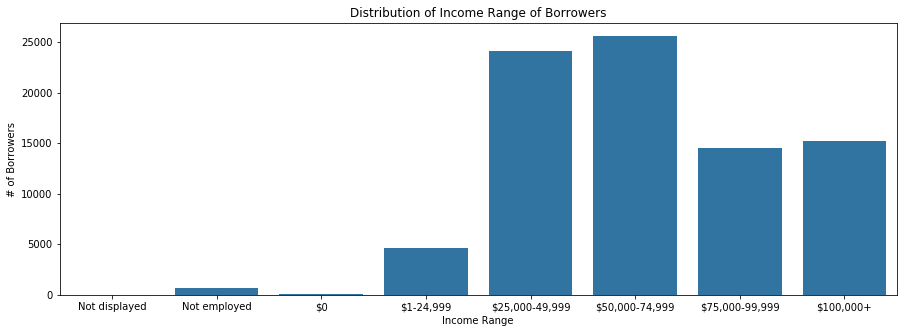

```python
# Plot for INCOMERANGE
plt.figure(figsize=[15, 5])
base_color = sb.color_palette()[0]
# Order the categorical variable type

sb.countplot(data = data, x = 'IncomeRange', color = base_color)
plt.ylabel('# of Borrowers')
plt.xlabel('Income Range')
plt.title('Distribution of Income Range of Borrowers');
```

### Observation

Consumers median annual income is beween $50k-$75k. With a small percentage in lower income and unemplpyed. Showing that majority of loans go to middle income consumers.

### What is the distribution of the Prosper Ratings in the dataset?

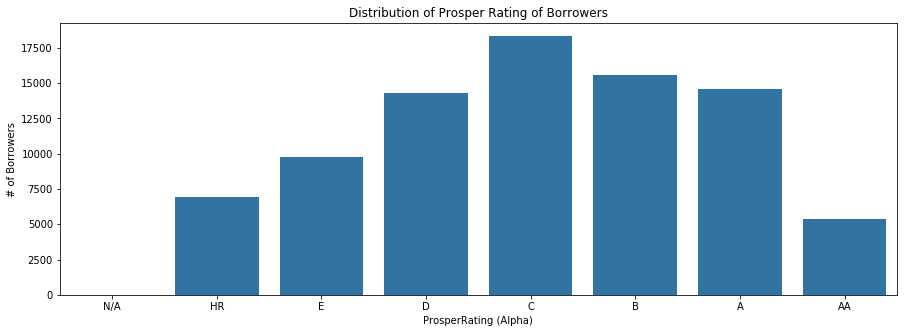

```python
# Plot for Prosper Rating
plt.figure(figsize=[15, 5])
base_color = sb.color_palette()[0]
# Order the categorical variable type

sb.countplot(data = data, x = 'ProsperRating (Alpha)', color = base_color)
plt.ylabel('# of Borrowers')
plt.xlabel('ProsperRating (Alpha)')
plt.title('Distribution of Prosper Rating of Borrowers');
```

### Observations

The prosper rating ins normally distributed.

### What is the distribution of the Employment Duration?

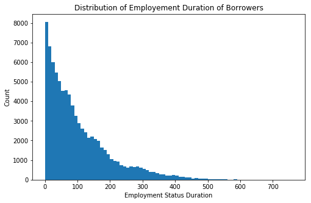

```python
binsize = 10
bins = np.arange(0, data['EmploymentStatusDuration'].max()+binsize, binsize)

plt.figure(figsize=[8, 5])
plt.hist(data = data, x = 'EmploymentStatusDuration', bins = bins)
plt.xlabel('Employment Status Duration')
plt.ylabel('Count')
plt.title('Distribution of Employement Duration of Borrowers')
plt.show()
```

### Observation

As previously states, employment duration is skewed to the right. Most borrowers are employed for under 10 years.

```python
#check out log distribution of data for employment duration as it is skewed to the right
np.log10(data['EmploymentStatusDuration'].describe())
```

```
count    4.928570
mean     2.013070
std      1.987125
min          -inf
25%      1.477121
50%      1.869232
75%      2.170262
max      2.877947
Name: EmploymentStatusDuration, dtype: float64
```

```
Text(0.5,1,'Log Distribution of Employment Duration')
```

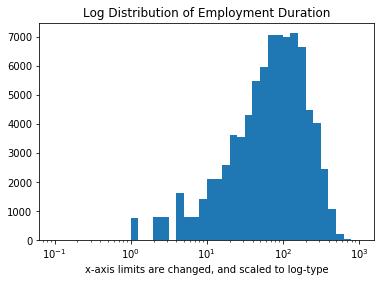

```python
# Axis transformation
# Bin size
bins = 10 ** np.arange(-1, 3+0.1, 0.1)
plt.hist(data=data, x='EmploymentStatusDuration', bins=bins);

# The argument in the xscale() represents the axis scale type to apply.
# The possible values are: {"linear", "log", "symlog", "logit", ...}
plt.xscale('log')

# Apply x-axis label
# Documentatin: [matplotlib `xlabel`](https://matplotlib.org/api/_as_gen/matplotlib.pyplot.xlabel.html))
plt.xlabel('x-axis limits are changed, and scaled to log-type')
plt.title('Log Distribution of Employment Duration')
```

After transforming the data to log, the data looks more normally distributed.

### What is the distribution of Stated Monthly Income?

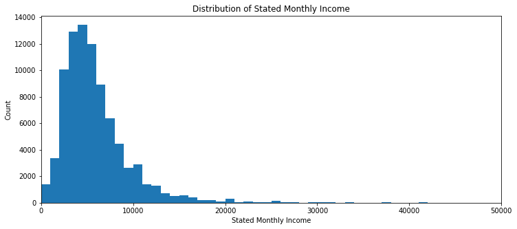

```python
binsize = 1000
bins = np.arange(0, data['StatedMonthlyIncome'].max()+binsize, binsize)

plt.figure(figsize=[12, 5])
plt.hist(data = data, x = 'StatedMonthlyIncome', bins = bins)
plt.xlabel('Stated Monthly Income')
plt.ylabel('Count')
plt.xlim(0,50000)
plt.title('Distribution of Stated Monthly Income')
plt.show()
```

### What is the distribution, ranges and median of all numeric variables?

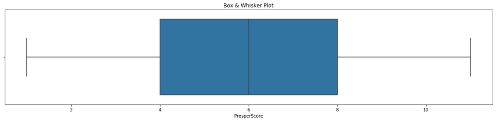

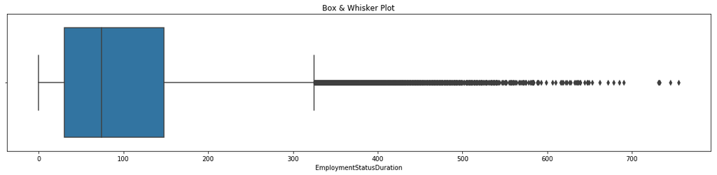

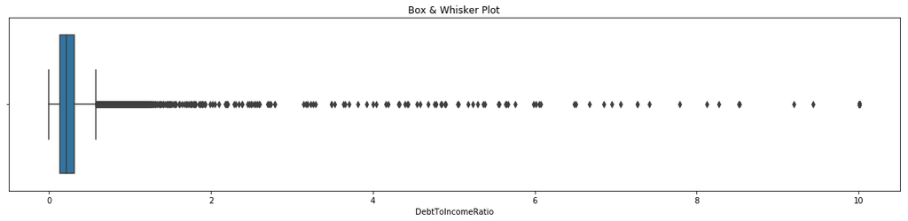

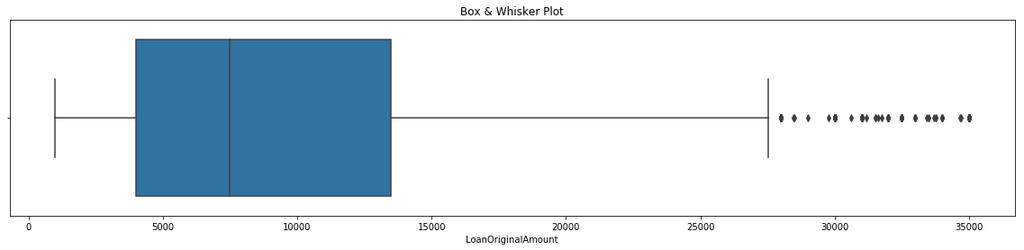

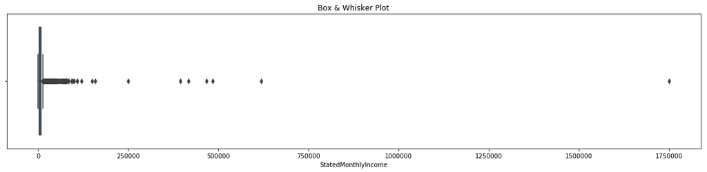

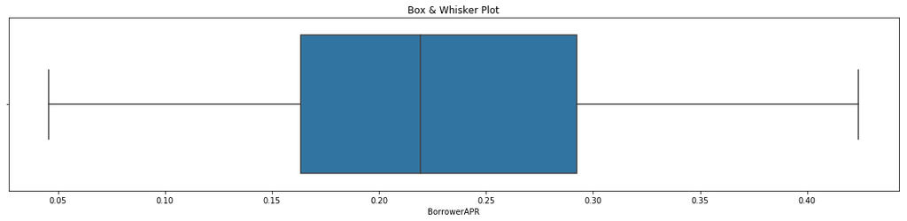

```python
#Plot box & whisker plots for numeric variables and see if they speak more about the distribution
for i, col in enumerate(data_numeric.columns):
    plt.figure(i, figsize=(20,4))
    plt.title('Box & Whisker Plot' )
    sb.boxplot(data_numeric[col])
    plt.show();
```

## Overall

> The borrower APR and Prosper score were normally distributed, likewise for the income ranges, while Employment duration and debt to income ratio needed to be transformed by a log function to assess normallity, which they were once transformed.

## Bivariate Exploration

> Here we shall look at the interaction between two variables

### What is the relationship between the variables in the dataset? Any correlations?

```
Text(0.5,1,'Correlation Matrix')
```

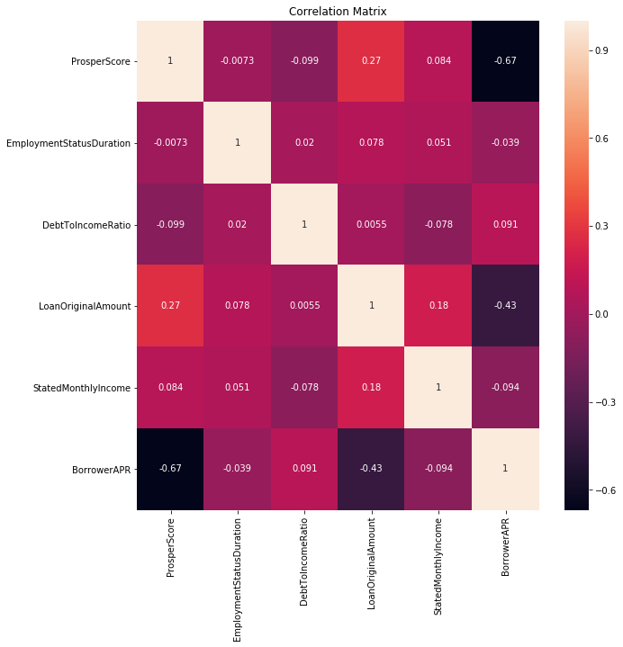

```python
#First assess the correlation between the numeric variables
plt.figure(figsize = [10, 10])
dataplot=sb.heatmap(data_numeric.corr(), annot=True)
plt.title('Correlation Matrix' )
```

### Observation

A relatively medium to strong relationship between prosper score and Borrower APR, which confirms the hypothesis that the better the prosper score, the better the interest rate (APR) the borrrower will receive. There is a medium relation betwen borrower APR and loan original amount, this makes sense and relates that the larger the loan amount, smaller the interest rate.

### What is the relationship between Prosper Score & Loan Amount and Prosper Score & Borrower APR?

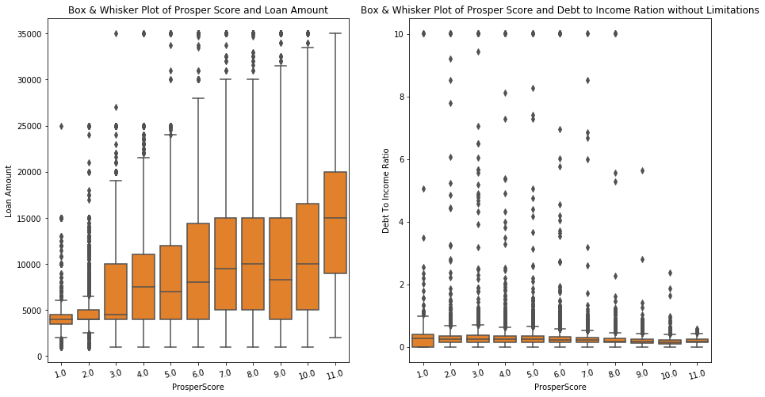

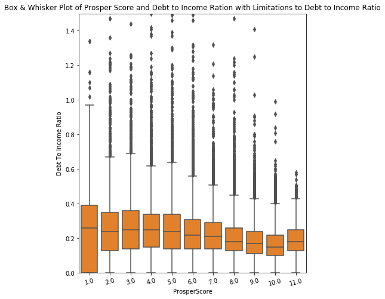

```python
plt.figure(figsize = [15, 8])
base_color = sb.color_palette()[1]

plt.subplot(1,2,1)
sb.boxplot(data = data, x = 'ProsperScore', y = 'LoanOriginalAmount' ,color = base_color)
plt.xticks(rotation = 15)
plt.ylabel('Loan Amount')
plt.title('Box & Whisker Plot of Prosper Score and Loan Amount')


plt.subplot(1,2,2)
sb.boxplot(data = data, x = 'ProsperScore', y = 'DebtToIncomeRatio' ,color = base_color)
plt.xticks(rotation = 15)
plt.ylabel('Debt To Income Ratio')
plt.title('Box & Whisker Plot of Prosper Score and Debt to Income Ration without Limitations')
plt.show()

plt.figure(figsize = [15, 8])
plt.subplot(1,2,2)
sb.boxplot(data = data, x = 'ProsperScore', y = 'DebtToIncomeRatio' ,color = base_color)
plt.xticks(rotation = 15)
plt.ylabel('Debt To Income Ratio')
plt.ylim(0,1.5)
plt.title('Box & Whisker Plot of Prosper Score and Debt to Income Ration with Limitations to Debt to Income Ratio')
plt.show()
```

### Observation

The first graph indicates that with the better the prosper score, on average the loan amount is bigger. So consumers with better prosper scores receive bigger loan amounts.

Debt to income ratio has less variation when the prosper score is higher and slightly lower debt to income ratio, while, a low prosper scores are more variable with debt to income ratio and slightly higher. This indicates that People with higher Prosper scores generally have low debt to income ratios, while people with low prosper scores range from low to high debt to income ratios.

### Taking a closer look at the distribution of the Prosper Score and Loan Amount

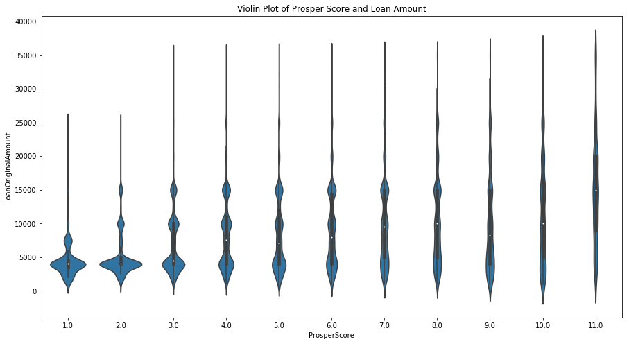

```python
plt.figure(figsize = [15, 8])
base_color = sb.color_palette()[0]
bins = np.arange(0, 35000, 1500)
sb.violinplot(data = data, x = 'ProsperScore' , y = 'LoanOriginalAmount', bins=bins, color = base_color)
plt.title('Violin Plot of Prosper Score and Loan Amount')
plt.show()
```

### Observation

Lower prosper scores tend to be skewed towards smaller loan amounts, while higher prosper scores are spread out between loan amounts.

### Taking a closer look at Borrower APR and Prosper Score

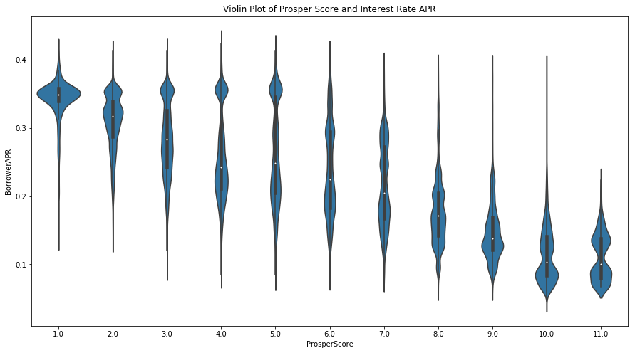

```python
#Borrow APR and Prosper Score relationship
plt.figure(figsize = [15, 8])
base_color = sb.color_palette()[0]
bins = np.arange(0, 35000, 1500)
sb.violinplot(data = data, x = 'ProsperScore' , y = 'BorrowerAPR', bins=bins, color = base_color)
plt.title('Violin Plot of Prosper Score and Interest Rate APR')
plt.show()
```

### Observations

Low Prosper score get higher interest rates become they are deemed riskier, while higher prosper score receives lower interest rates as they are considered less risky.

### What is the distribution and relationship between Employmen Status, Loan AMount & Borrower APR?

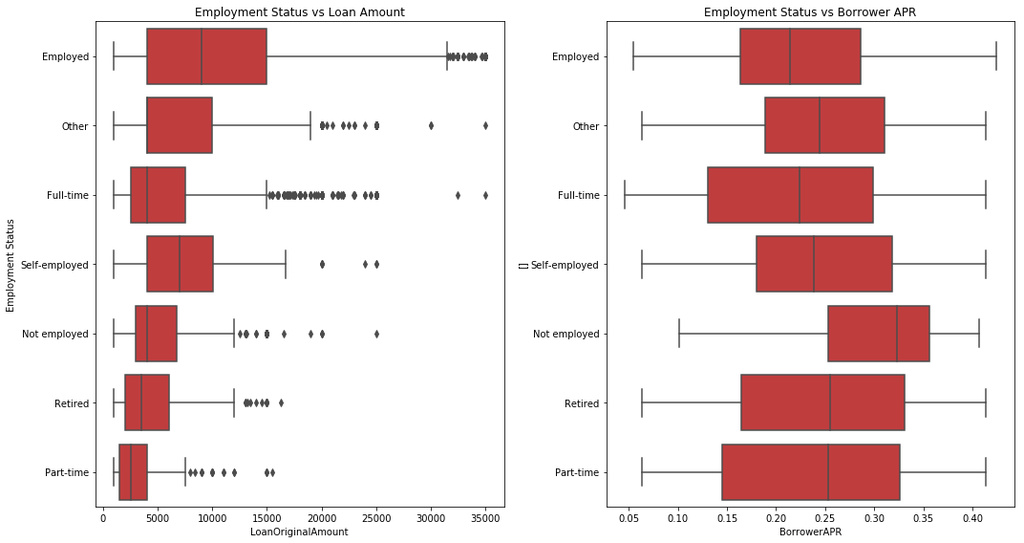

```python
#Assess if employment status has an influence on Borrow APR
plt.figure(figsize = [15, 8])
base_color = sb.color_palette()[3]

plt.subplot(1,2,1)
sb.boxplot(data = data, y = 'EmploymentStatus', x = 'LoanOriginalAmount' ,color = base_color, orient='h')
plt.xticks(rotation = 0)
plt.ylabel('Employment Status')
plt.title('Employment Status vs Loan Amount')

plt.subplot(1,2,2)
sb.boxplot(data = data, y = 'EmploymentStatus', x = 'BorrowerAPR' ,color = base_color, orient='h')
plt.xticks(rotation = 0)
plt.ylabel([])
plt.title('Employment Status vs Borrower APR');

plt.tight_layout()
```

### Observation

Employed and Self employed have a higher median loan amount compared to people who are not employed, retired or part-time employed. This makes sense as employed and self employed have greater chance of paying back the loan - hence they will receive a greate loan amount.

While interest rate does not seem to be grately effected by employment status. However, people who are not emplyed tend to have a higher interest rate than those are are employed.

### What is the relationship and distribtion between Loan Category, Loan Amount & Borrower APR?

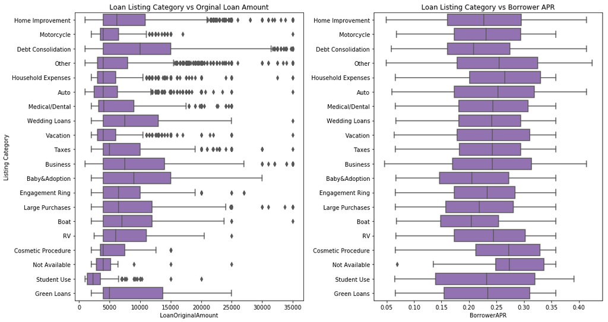

```python
#lets assess if the type of loan will effect the interest rate and loan amount
plt.figure(figsize = [15, 8])
base_color = sb.color_palette()[4]

plt.subplot(1,2,1)
sb.boxplot(data = data, y = 'ListingCategory', x = 'LoanOriginalAmount' ,color = base_color, orient='h')
plt.xticks(rotation = 0)
plt.ylabel('Listing Category')
plt.title('Loan Listing Category vs Orginal Loan Amount')

plt.subplot(1,2,2)
sb.boxplot(data = data, y = 'ListingCategory', x = 'BorrowerAPR' ,color = base_color, orient='h')
plt.xticks(rotation = 0)
plt.ylabel('')
plt.title('Loan Listing Category vs Borrower APR');

plt.tight_layout()
```

### Observation

Debt consolidation has the highest median loan amount, while motocyle, household expenses, auto, vacation and student use have the lowest loan amount. While no significant trends for Interest rate when comparing to the listing category. Debt consolidation, baby and adoption and boat have the lowest median interest rates. Debt that is for unknown/information not avaiable and cosmetic procedurers have a slightly higher median interest rate.